# Winter_project

Kikalova Tatiana

4/06/2022

## Data Set Information

The data set consists of the expression levels of 77 proteins/protein modifications that produced detectable signals in the nuclear fraction of cortex. There are 38 control mice and 34 trisomic mice (Down syndrome), for a total of 72 mice. In the experiments, 15 measurements were registered of each protein per sample/mouse. Therefore, for control mice, there are 38x15, or 570 measurements, and for trisomic mice, there are 34x15, or 510 measurements. The dataset contains a total of 1080 measurements per protein. Each measurement can be considered as an independent sample/mouse.

The eight classes of mice are described based on features such as genotype, behavior and treatment. According to genotype, mice can be control or trisomic. According to behavior, some mice have been stimulated to learn (context-shock) and others have not (shock-context) and in order to assess the effect of the drug memantine in recovering the ability to learn in trisomic mice, some mice have been injected with the drug and others have not.

Classes:

- c-CS-s: control mice, stimulated to learn, injected with saline (9 mice)
- c-CS-m: control mice, stimulated to learn, injected with memantine (10 mice)
- c-SC-s: control mice, not stimulated to learn, injected with saline (9 mice)
- c-SC-m: control mice, not stimulated to learn, injected with memantine (10 mice)
- t-CS-s: trisomy mice, stimulated to learn, injected with saline (7 mice)
- t-CS-m: trisomy mice, stimulated to learn, injected with memantine (9 mice)
- t-SC-s: trisomy mice, not stimulated to learn, injected with saline (9 mice)
- t-SC-m: trisomy mice, not stimulated to learn, injected with memantine (9 mice)

The aim is to identify subsets of proteins that are discriminant between the classes.

## EDA (5 points)

Make a description of the dataset:

- how many mice were in the experiment
- which groups can you identify
- how balanced are these groups
- how many complete observations (without NA)

```r
library(dplyr)
library(caret)
library("readxl")
library(psych)
library(tidyr)
```

```r
m_df <- read_excel("..\\data_folder\\Data_Cortex_Nuclear.xls")
describe(m_df)
```

```
##                 vars    n   mean     sd median trimmed    mad   min     max
## MouseID*           1 1080 540.50 311.91 540.50  540.50 400.30  1.00 1080.00
## DYRK1A_N           2 1077   0.43   0.25   0.37    0.39   0.13  0.15    2.52
## ITSN1_N            3 1077   0.62   0.25   0.57    0.58   0.16  0.25    2.60
## BDNF_N             4 1077   0.32   0.05   0.32    0.32   0.05  0.12    0.50
## NR1_N              5 1077   2.30   0.35   2.30    2.30   0.35  1.33    3.76
## NR2A_N             6 1077   3.84   0.93   3.76    3.80   0.93  1.74    8.48
## pAKT_N             7 1077   0.23   0.04   0.23    0.23   0.04  0.06    0.54
## pBRAF_N            8 1077   0.18   0.03   0.18    0.18   0.02  0.06    0.32
## pCAMKII_N          9 1077   3.54   1.30   3.33    3.45   1.43  1.34    7.46
## pCREB_N           10 1077   0.21   0.03   0.21    0.21   0.03  0.11    0.31
## pELK_N            11 1077   1.43   0.47   1.36    1.38   0.25  0.43    6.11
## pERK_N            12 1077   0.55   0.35   0.44    0.49   0.19  0.15    3.57
## pJNK_N            13 1077   0.31   0.05   0.32    0.32   0.05  0.05    0.49
## PKCA_N            14 1077   0.32   0.05   0.31    0.32   0.05  0.19    0.47
## pMEK_N            15 1077   0.28   0.05   0.28    0.27   0.04  0.06    0.46
## pNR1_N            16 1077   0.83   0.12   0.82    0.82   0.12  0.50    1.41
## pNR2A_N           17 1077   0.73   0.19   0.72    0.72   0.19  0.28    1.41
## pNR2B_N           18 1077   1.56   0.27   1.56    1.56   0.27  0.30    2.72
## pPKCAB_N          19 1077   1.53   0.48   1.37    1.49   0.42  0.57    3.06
## pRSK_N            20 1077   0.44   0.07   0.44    0.44   0.06  0.10    0.65
## AKT_N             21 1077   0.68   0.13   0.68    0.68   0.12  0.06    1.18
## BRAF_N            22 1077   0.38   0.22   0.33    0.34   0.10  0.14    2.13
## CAMKII_N          23 1077   0.36   0.05   0.36    0.36   0.05  0.21    0.59
## CREB_N            24 1077   0.18   0.03   0.18    0.18   0.02  0.11    0.32
## ELK_N             25 1062   1.17   0.34   1.10    1.13   0.26  0.50    2.80
## ERK_N             26 1077   2.47   0.65   2.40    2.43   0.63  1.13    5.20
## GSK3B_N           27 1077   1.17   0.24   1.16    1.16   0.21  0.15    2.48
## JNK_N             28 1077   0.24   0.03   0.24    0.24   0.03  0.05    0.39
## MEK_N             29 1073   0.27   0.04   0.27    0.27   0.04  0.15    0.42
## TRKA_N            30 1077   0.69   0.12   0.70    0.70   0.11  0.20    1.00
## RSK_N             31 1077   0.17   0.03   0.17    0.17   0.03  0.11    0.31
## APP_N             32 1077   0.40   0.06   0.40    0.40   0.06  0.24    0.63
## Bcatenin_N        33 1062   2.15   0.44   2.11    2.13   0.45  1.13    3.68
## SOD1_N            34 1077   0.54   0.28   0.44    0.50   0.22  0.22    1.87
## MTOR_N            35 1077   0.45   0.07   0.45    0.45   0.06  0.20    0.68
## P38_N             36 1077   0.42   0.09   0.41    0.41   0.08  0.23    0.93
## pMTOR_N           37 1077   0.76   0.12   0.76    0.76   0.12  0.17    1.12
## DSCR1_N           38 1077   0.59   0.10   0.58    0.58   0.08  0.16    0.92
## AMPKA_N           39 1077   0.37   0.06   0.36    0.36   0.05  0.23    0.70
```

[output cut: 111 more lines]

```
## pGSK3B_Tyr216_N    0.63 -0.11     0.04 0.00
## SHH_N              0.20  0.96     1.85 0.00
## BAD_N              0.19  0.81     0.58 0.00
## BCL2_N             0.18  1.21     1.94 0.00
## pS6_N              0.09 -0.08    -0.39 0.00
## pCFOS_N            0.17  1.15     2.24 0.00
## SYP_N              0.50  0.13     0.50 0.00
## H3AcK18_N          0.40  1.75     4.86 0.00
## EGR1_N             0.26  1.10     1.53 0.00
## H3MeK4_N           0.31  0.98     0.81 0.00
## CaNA_N             1.54  0.18    -0.74 0.01
## Genotype*          1.00  0.11    -1.99 0.02
## Treatment*         1.00  0.11    -1.99 0.02
## Behavior*          1.00 -0.06    -2.00 0.02
## class*             7.00  0.08    -1.25 0.07
```

**- how many mice were in the experiment?**

```r
m_m <- strsplit(m_df$MouseID, "_")
m_m_u <- unique(do.call(rbind, m_m)[,1])
length(m_m_u)
```

```
## [1] 72
```

**- which groups can you identify**

```r
unique(m_df$class)
```

```
## [1] "c-CS-m" "c-SC-m" "c-CS-s" "c-SC-s" "t-CS-m" "t-SC-m" "t-CS-s" "t-SC-s"
```

**- how balanced are these groups**

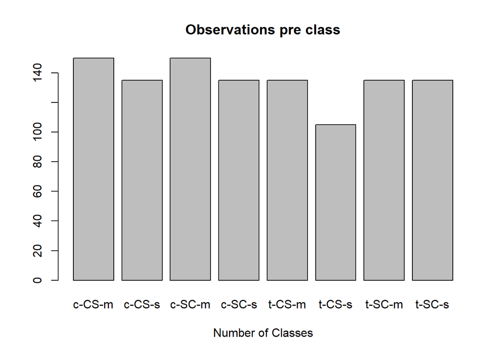

```r
# Simple Bar Plot
counts <- table(m_df$class)
barplot(counts, main="Observations pre class",
   xlab="Number of Classes")
```

The class distribution looks balanced enough for Linear regression.

**- how many complete observations (without NA)**

```r
completerecords <- na.omit(m_df)
nrow(completerecords)
```

```
## [1] 552
```

## Task 2

**Are there any differences in the level of production of BDNF_N depending on the class in the experiment (10 points)**

```r
data_summary <- function(data, varname, groupnames){
  require(plyr)
  summary_func <- function(x, col){
    c(mean = mean(x[[col]], na.rm=TRUE),
      sd = sd(x[[col]], na.rm=TRUE))
  }
  data_sum<-ddply(data, groupnames, .fun=summary_func,
                  varname)
 return(data_sum)
}
```

```r
bdnf_data <- data_summary(m_df, varname="BDNF_N",
                    groupnames=("class"))
# Convert class to a factor variable
bdnf_data$class=as.factor(bdnf_data$class)
head(bdnf_data)
```

```
##    class      mean         sd
## 1 c-CS-m 0.3392174 0.04688325
## 2 c-CS-s 0.3423153 0.05488543
## 3 c-SC-m 0.2909458 0.03858719
## 4 c-SC-s 0.3133925 0.04363735
## 5 t-CS-m 0.3127322 0.05117537
## 6 t-CS-s 0.3054604 0.04334970
```

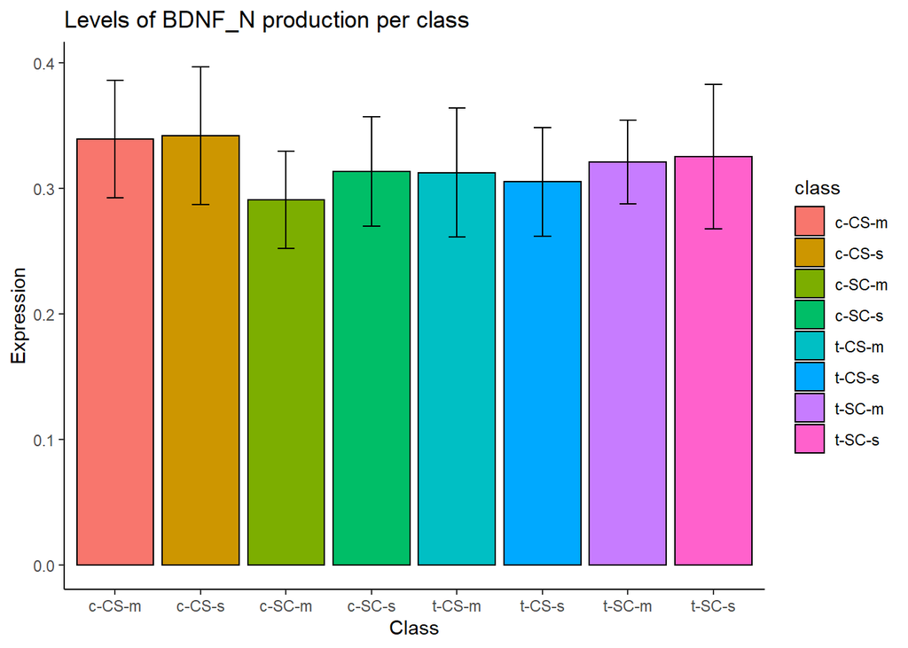

```r
library(ggplot2)
p<- ggplot(bdnf_data, aes(x=class, y=mean, fill=class)) +
  geom_bar(stat="identity", color="black",
           position=position_dodge()) +
  geom_errorbar(aes(ymin=mean-sd, ymax=mean+sd), width=.2,
                 position=position_dodge(.9))

p+labs(title="Levels of BDNF_N production per class", x="Class", y = "Expression")+
   theme_classic()
```

## Task 3

**Try to build a linear model that can predict the level of production of the ERBB4_N protein** **based on data on other proteins in the experiment (15 points)**

- to diagnose the resulting linear model
- explain why this is a good/not good solution

```r
# cutting the prediction parameters
drop <- c("MouseID", "Genotype",    "Treatment", "Behavior",    "class")
X_m_df <- completerecords[,!(names(completerecords) %in% drop)]
```

```r
#split data into training and test
set.seed(666)

sample <- sample.int(n = nrow(X_m_df), size = floor(.8*nrow(X_m_df)), replace = F)

train <-  X_m_df[sample, ]
test <-  X_m_df[-sample, ]
```

• Standardize your data (but not the target variable).

```r
# names of variables I don't want to scale
varnames <- c("ERBB4_N")

# index vector of columns which must not be scaled
index <- names(train) %in% varnames

# scale only the columns not in index
temp <- scale(train[, !index])
train[, !index] <- temp

# get the means and standard deviations from temp, to scale test too
means <- attr(temp, "scaled:center")
standard_deviations <- attr(temp, "scaled:scale")

# scale test
test[, !index] <- scale(test[, !index], center = means, scale = standard_deviations)
```

• Build a linear model that can predict the level of production of the ERBB4_N protein based on data on other proteins in the experiment

```r
#Build Model
model <- lm(ERBB4_N ~ . - ERBB4_N, data=train)

# Adjusted R-squared:  0.844
summary(model)
```

```
##
## Call:
## lm(formula = ERBB4_N ~ . - ERBB4_N, data = train)
##
## Residuals:
##        Min         1Q     Median         3Q        Max
## -0.0190767 -0.0032910 -0.0002167  0.0031615  0.0302505
##
## Coefficients: (1 not defined because of singularities)
##                   Estimate Std. Error t value Pr(>|t|)
## (Intercept)      1.563e-01  2.838e-04 550.601  < 2e-16 ***
## DYRK1A_N        -1.516e-03  1.326e-03  -1.143 0.253593
## ITSN1_N         -5.542e-04  2.327e-03  -0.238 0.811891
## BDNF_N           1.186e-03  1.416e-03   0.838 0.402579
## NR1_N           -4.855e-03  2.916e-03  -1.665 0.096700 .
## NR2A_N           2.913e-04  1.434e-03   0.203 0.839103
## pAKT_N           2.934e-03  1.373e-03   2.137 0.033236 *
## pBRAF_N         -1.350e-03  8.899e-04  -1.517 0.130030
## pCAMKII_N        7.988e-04  1.249e-03   0.640 0.522841
## pCREB_N         -2.715e-03  1.211e-03  -2.241 0.025607 *
## pELK_N           5.802e-05  4.552e-04   0.127 0.898646
## pERK_N          -4.415e-03  2.167e-03  -2.038 0.042299 *
## pJNK_N          -4.440e-03  1.529e-03  -2.903 0.003917 **
## PKCA_N          -1.266e-03  1.889e-03  -0.670 0.503267
## pMEK_N           6.511e-04  1.416e-03   0.460 0.645909
## pNR1_N          -2.013e-03  1.994e-03  -1.010 0.313349
## pNR2A_N          2.301e-03  1.619e-03   1.422 0.155958
## pNR2B_N          4.439e-03  2.115e-03   2.099 0.036519 *
## pPKCAB_N         2.973e-03  1.624e-03   1.831 0.067866 .
## pRSK_N           6.743e-04  1.173e-03   0.575 0.565883
## AKT_N            6.059e-05  1.192e-03   0.051 0.959496
## BRAF_N           3.713e-03  1.898e-03   1.956 0.051216 .
## CAMKII_N        -4.405e-04  1.134e-03  -0.389 0.697849
## CREB_N          -3.541e-04  9.637e-04  -0.367 0.713510
## ELK_N            2.588e-03  1.683e-03   1.538 0.125021
## ERK_N            3.059e-03  2.168e-03   1.411 0.158992
## GSK3B_N         -1.346e-03  1.764e-03  -0.763 0.445911
## JNK_N           -7.249e-04  1.303e-03  -0.556 0.578217
## MEK_N            6.168e-04  1.114e-03   0.554 0.580125
## TRKA_N           2.387e-03  2.628e-03   0.909 0.364134
```

[output cut: 38 more lines]

```
## BAD_N           -1.445e-03  1.103e-03  -1.310 0.191045
## BCL2_N           2.288e-04  8.414e-04   0.272 0.785844
## pS6_N                   NA         NA      NA       NA
## pCFOS_N         -2.571e-04  7.355e-04  -0.350 0.726911
## SYP_N            1.204e-03  8.719e-04   1.381 0.168041
## H3AcK18_N        9.583e-04  1.843e-03   0.520 0.603442
## EGR1_N           3.331e-04  1.162e-03   0.287 0.774565
## H3MeK4_N        -2.903e-04  1.217e-03  -0.239 0.811626
## CaNA_N          -6.191e-04  1.280e-03  -0.484 0.628922
## ---
## Signif. codes:  0 '***' 0.001 '**' 0.01 '*' 0.05 '.' 0.1 ' ' 1
##
## Residual standard error: 0.00596 on 365 degrees of freedom
## Multiple R-squared:  0.8706, Adjusted R-squared:  0.844
## F-statistic: 32.73 on 75 and 365 DF,  p-value: < 2.2e-16
```

```r
# predict using the Model
predictions <- model %>% predict(subset(test, select = -ERBB4_N))
predictions
```

```
##          1          2          3          4          5          6          7
## 0.15586153 0.09761121 0.10964183 0.14926198 0.16014842 0.16312469 0.16427221
##          8          9         10         11         12         13         14
## 0.15860351 0.14697352 0.15301847 0.14448372 0.14875385 0.16226781 0.15071937
##         15         16         17         18         19         20         21
## 0.14926090 0.15452385 0.14180694 0.13646890 0.14730108 0.14446772 0.14423417
##         22         23         24         25         26         27         28
## 0.13061337 0.11853717 0.18001819 0.16692986 0.17037558 0.14818200 0.13931834
##         29         30         31         32         33         34         35
## 0.16420736 0.15317271 0.15514338 0.13724369 0.13469897 0.14689863 0.15367479
##         36         37         38         39         40         41         42
## 0.16799322 0.16879996 0.16808381 0.16573013 0.15849887 0.16550546 0.16292072
##         43         44         45         46         47         48         49
## 0.15838297 0.16094764 0.14457617 0.15530586 0.15489540 0.15266179 0.16535359
##         50         51         52         53         54         55         56
## 0.16443547 0.16509427 0.14115897 0.15201161 0.14675949 0.16689741 0.16550257
##         57         58         59         60         61         62         63
## 0.14835730 0.13962638 0.13684459 0.15155921 0.14796833 0.14036868 0.16076341
##         64         65         66         67         68         69         70
## 0.14301554 0.13670200 0.13787411 0.14473876 0.15144280 0.15280210 0.14486586
##         71         72         73         74         75         76         77
## 0.15591506 0.15472896 0.14691154 0.14114916 0.15423510 0.14513346 0.14209378
##         78         79         80         81         82         83         84
## 0.16685884 0.19006835 0.18023384 0.18337936 0.18833893 0.18828846 0.16786181
##         85         86         87         88         89         90         91
## 0.16658099 0.17031301 0.16966234 0.17252759 0.16217884 0.15358289 0.16704131
##         92         93         94         95         96         97         98
## 0.16097161 0.15493258 0.14890658 0.12546470 0.16018496 0.15333430 0.15055613
##         99        100        101        102        103        104        105
## 0.16418862 0.14823935 0.16941580 0.15231719 0.15824084 0.14816048 0.15884204
##        106        107        108        109        110        111
## 0.15404762 0.15920573 0.17349452 0.14685518 0.17867628 0.18130539
```

```r
compare <- data.frame(actual = test$ERBB4_N,
                      predicted = predictions)
compare
```

```
##        actual  predicted
## 1   0.1673860 0.15586153
## 2   0.1083058 0.09761121
## 3   0.1172257 0.10964183
## 4   0.1460204 0.14926198
## 5   0.1499024 0.16014842
## 6   0.1632963 0.16312469
## 7   0.1548178 0.16427221
## 8   0.1623589 0.15860351
## 9   0.1448499 0.14697352
## 10  0.1536720 0.15301847
## 11  0.1401828 0.14448372
## 12  0.1388790 0.14875385
## 13  0.1601771 0.16226781
## 14  0.1536348 0.15071937
```

[output cut: 97 more lines]

```r
# 0.006441225
error <- RMSE(predictions, test$ERBB4_N)
error
```

```
## [1] 0.006441225
```

## Task 4

**Do a PCA (15 points)**

- ordination
- plot factor loads
- determine what percentage each component explains
- build a 3D plot for the first 3 components

```r
#install.packages("vegan")
library(vegan)
```

```r
# Principal Component Analysis:
train_pc <- prcomp(train, scale = TRUE)

#compute standard deviation of each principal component
std_dev <- train_pc$sdev

#compute variance
pr_var <- std_dev^2

#check variance of first 10 components
pr_var[1:10]
```

```
##  [1] 23.289934 13.603467  7.772314  7.137548  3.237246  2.961014  2.352541
##  [8]  2.200125  1.884746  1.291611
```

```r
#proportion of variance explained
prop_varex <- pr_var/sum(pr_var)
prop_varex[1:20]
```

```
##  [1] 0.302466669 0.176668403 0.100939137 0.092695423 0.042042159 0.038454729
##  [7] 0.030552479 0.028573052 0.024477223 0.016774169 0.014691593 0.012795755
## [13] 0.010766168 0.008916597 0.007749431 0.007009312 0.006525815 0.005706074
## [19] 0.005396961 0.005127633
```

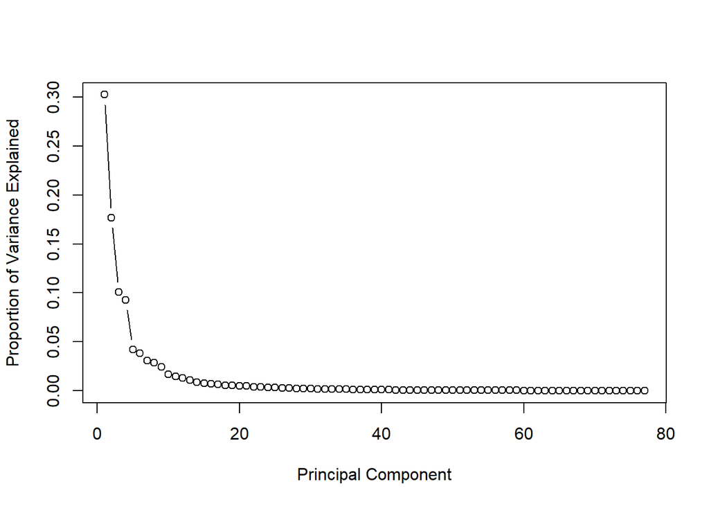

```r
#scree plot
plot(prop_varex, xlab = "Principal Component",
     ylab = "Proportion of Variance Explained",
     type = "b")
```

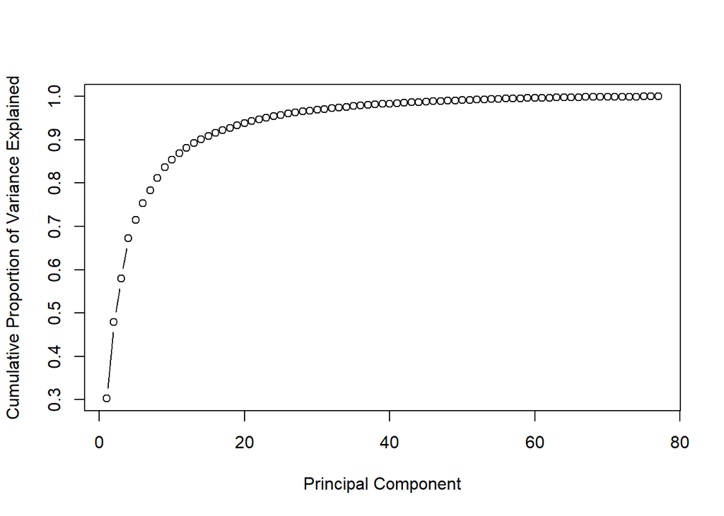

```r
#cumulative scree plot
plot(cumsum(prop_varex), xlab = "Principal Component",
       ylab = "Cumulative Proportion of Variance Explained",
       type = "b")
```

```r
eigenvals(train_pc)
```

```
##       PC1       PC2       PC3       PC4       PC5       PC6       PC7       PC8
## 23.289934 13.603467  7.772314  7.137548  3.237246  2.961014  2.352541  2.200125
##       PC9      PC10      PC11      PC12      PC13      PC14      PC15      PC16
##  1.884746  1.291611  1.131253  0.985273  0.828995  0.686578  0.596706  0.539717
##      PC17      PC18      PC19      PC20      PC21      PC22      PC23      PC24
##  0.502488  0.439368  0.415566  0.394828  0.373180  0.314827  0.282460  0.253101
##      PC25      PC26      PC27      PC28      PC29      PC30      PC31      PC32
##  0.243719  0.215840  0.210763  0.180628  0.161521  0.155958  0.144909  0.129660
##      PC33      PC34      PC35      PC36      PC37      PC38      PC39      PC40
##  0.125027  0.122084  0.119299  0.102139  0.097813  0.092109  0.088306  0.082147
##      PC41      PC42      PC43      PC44      PC45      PC46      PC47      PC48
##  0.075905  0.069802  0.068339  0.066318  0.062106  0.060828  0.057376  0.053678
##      PC49      PC50      PC51      PC52      PC53      PC54      PC55      PC56
##  0.053015  0.051884  0.048750  0.046024  0.042051  0.040310  0.038640  0.035687
##      PC57      PC58      PC59      PC60      PC61      PC62      PC63      PC64
##  0.034052  0.031763  0.030224  0.028313  0.026786  0.025869  0.025635  0.023041
##      PC65      PC66      PC67      PC68      PC69      PC70      PC71      PC72
##  0.020460  0.019175  0.018524  0.017200  0.015820  0.012868  0.011085  0.010003
##      PC73      PC74      PC75      PC76      PC77
##  0.009692  0.008375  0.007736  0.005856  0.000000
```

```r
#let's check broken stick plot
bstick(train_pc)
```

```
##        PC1        PC2        PC3        PC4        PC5        PC6        PC7
## 4.92750054 3.92750054 3.42750054 3.09416720 2.84416720 2.64416720 2.47750054
##        PC8        PC9       PC10       PC11       PC12       PC13       PC14
## 2.33464340 2.20964340 2.09853228 1.99853228 1.90762319 1.82428986 1.74736678
##       PC15       PC16       PC17       PC18       PC19       PC20       PC21
## 1.67593821 1.60927155 1.54677155 1.48794802 1.43239246 1.37976088 1.32976088
##       PC22       PC23       PC24       PC25       PC26       PC27       PC28
## 1.28214183 1.23668729 1.19320903 1.15154236 1.11154236 1.07308082 1.03604379
##       PC29       PC30       PC31       PC32       PC33       PC34       PC35
## 1.00032950 0.96584674 0.93251341 0.90025534 0.86900534 0.83870231 0.80929055
##       PC36       PC37       PC38       PC39       PC40       PC41       PC42
## 0.78071912 0.75294134 0.72591431 0.69959852 0.67395750 0.64895750 0.62456726
##       PC43       PC44       PC45       PC46       PC47       PC48       PC49
## 0.60075773 0.57750192 0.55477464 0.53255242 0.51081329 0.48953670 0.46870336
##       PC50       PC51       PC52       PC53       PC54       PC55       PC56
## 0.44829520 0.42829520 0.40868736 0.38945659 0.37058866 0.35207014 0.33388833
##       PC57       PC58       PC59       PC60       PC61       PC62       PC63
## 0.31603118 0.29848732 0.28124594 0.26429679 0.24763013 0.23123668 0.21510765
##       PC64       PC65       PC66       PC67       PC68       PC69       PC70
## 0.19923463 0.18360963 0.16822502 0.15307350 0.13814813 0.12344225 0.10894949
##       PC71       PC72       PC73       PC74       PC75       PC76       PC77
## 0.09466378 0.08057927 0.06669038 0.05299175 0.03947824 0.02614491 0.01298701
```

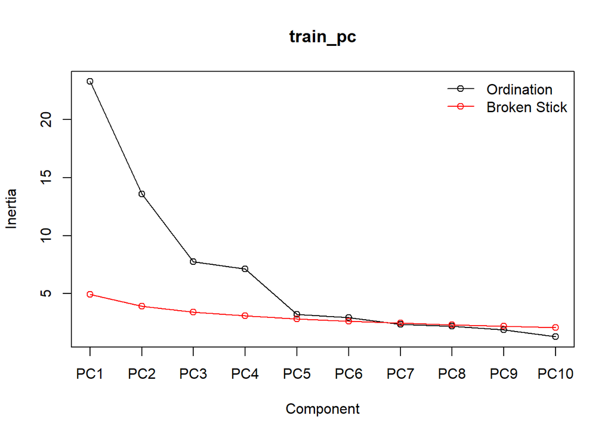

```r
screeplot(train_pc, type = "lines", bstick = TRUE)
```

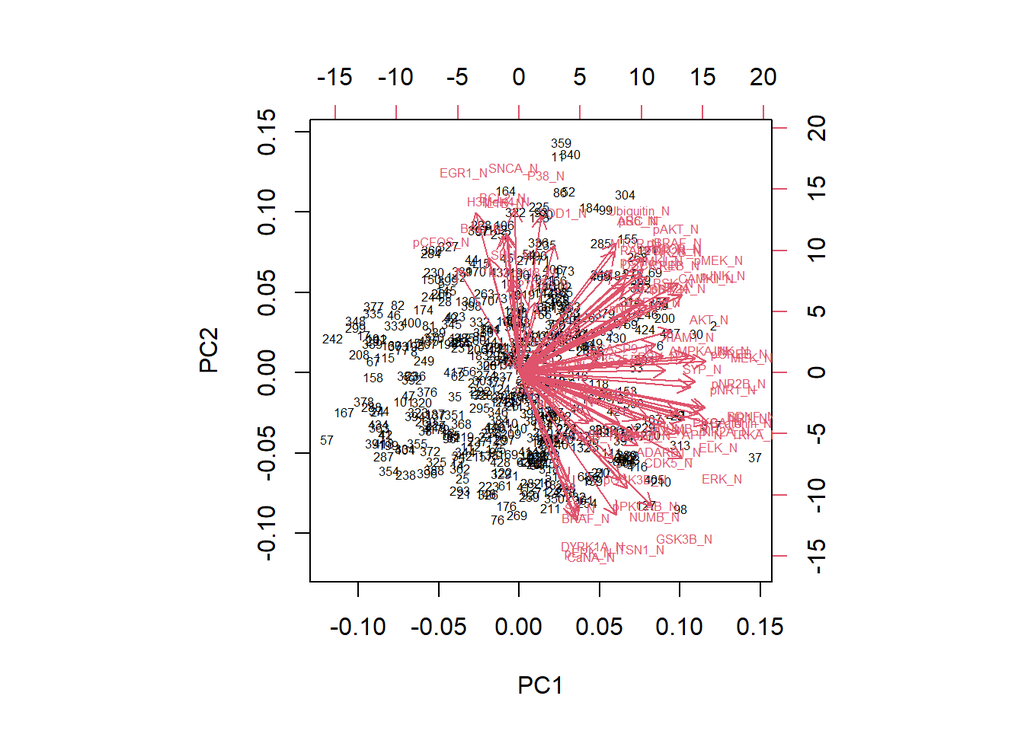

```r
biplot(train_pc, cex = 0.5, asp = 1)
```

```r
print(train_pc$rotation[,1:4])
```

```
##                          PC1          PC2           PC3          PC4
## DYRK1A_N         0.059814505 -0.183771202  0.0290013516 -0.115001243
## ITSN1_N          0.098292564 -0.187383116  0.0024988450 -0.069462606
## BDNF_N           0.187444288 -0.046616611  0.0258865341 -0.060510515
## NR1_N            0.184856802 -0.047821531  0.0874551941  0.047545148
## NR2A_N           0.166869681 -0.062595321  0.1283250084  0.045421873
## pAKT_N           0.126266548  0.151618739 -0.0600229876 -0.131343459
## pBRAF_N          0.125206042  0.136514872 -0.0415705576 -0.149568003
## pCAMKII_N        0.107010228  0.117669942 -0.0308208276 -0.025099087
## pCREB_N          0.177281371  0.019245773 -0.0638786206  0.016886655
## pELK_N           0.074302725 -0.063773749  0.1283310250 -0.080220580
## pERK_N           0.055583399 -0.190591288  0.0477401423 -0.089223956
## pJNK_N           0.164606505  0.102352690 -0.0224847300 -0.032368292
## PKCA_N           0.160461682 -0.053340261 -0.0729940456 -0.116829369
## pMEK_N           0.160791658  0.118162096 -0.0528758017 -0.089146447
## pNR1_N           0.172426346 -0.018661775  0.1298964710  0.072200785
## pNR2A_N          0.128994725  0.088664228  0.0605427239  0.160618393
## pNR2B_N          0.177512949 -0.011869400  0.1178663778  0.078636062
## pPKCAB_N         0.101807540 -0.141457895 -0.1051869539 -0.119382363
## pRSK_N           0.109490258  0.016391309 -0.1664852783 -0.134363780
## AKT_N            0.153613013  0.055186020  0.1068061392  0.068909303
## BRAF_N           0.054125545 -0.154477414  0.0156623107 -0.172799539
## CAMKII_N         0.151210258  0.098824927  0.0152663044 -0.125312825
## CREB_N           0.125600948  0.112828643 -0.0798160067 -0.175757644
## ELK_N            0.160876168 -0.079669133  0.0413744768  0.124796270
## ERK_N            0.164130819 -0.112430122  0.0761242235  0.078676771
## GSK3B_N          0.133370761 -0.175833852  0.0185253707 -0.089884063
## JNK_N            0.170294954  0.022513392 -0.0339694349 -0.150606867
## MEK_N            0.188097941  0.015667473 -0.0294169427 -0.028363124
## TRKA_N           0.190285409 -0.065793732 -0.0204543638 -0.011803423
## RSK_N            0.124904758  0.094229838 -0.0545744849 -0.175389518
## APP_N            0.147753223 -0.065752092 -0.0221277125 -0.113201828
## Bcatenin_N       0.179487311 -0.053734479  0.0631497642  0.089127852
## SOD1_N           0.035179780  0.168351268  0.0320204635  0.125243523
## MTOR_N           0.093668389  0.136010977  0.1810519085 -0.079471234
## P38_N            0.021898902  0.207263329  0.1334715236 -0.027250358
## pMTOR_N          0.123918810  0.130441313  0.1543867010  0.004183373
## DSCR1_N          0.106515851  0.113223981  0.1144177976 -0.144579596
## AMPKA_N          0.144802880  0.022326350  0.1862823846 -0.034412344
## NR2B_N           0.128576499  0.126788789  0.1407737287 -0.054019191
```

[output cut: 23 more lines]

```
## pCASP9_N         0.083025216  0.024902995 -0.0850795692  0.217596577
## PSD95_N          0.108185444  0.073702839 -0.0795583112  0.186528231
## SNCA_N          -0.004472406  0.215183626 -0.0007074428  0.059529894
## Ubiquitin_N      0.097282020  0.170681564 -0.0981694814  0.068801929
## pGSK3B_Tyr216_N  0.070041755 -0.067294488 -0.1993723803  0.021929345
## SHH_N           -0.006075251  0.123620678 -0.0703081081  0.021947961
## BAD_N           -0.030536880  0.152198291 -0.1819243580 -0.144157309
## BCL2_N          -0.013099103  0.184181245 -0.0931572267 -0.078107126
## pS6_N            0.095869233  0.160110179  0.0258298858  0.196036706
## pCFOS_N         -0.062587910  0.137591652 -0.0380312256 -0.022574479
## SYP_N            0.147761607  0.003255525 -0.0936875399  0.086785553
## H3AcK18_N        0.002270872  0.105320043 -0.2121437007  0.002649358
## EGR1_N          -0.044115618  0.211071371 -0.0606368073 -0.055900528
## H3MeK4_N        -0.016934536  0.180458076 -0.1931083479 -0.073785730
## CaNA_N           0.058440290 -0.194981416 -0.1295538747 -0.024064000
```

To get the direction of the arrows, we need to multiply the loadings in train_pc$rotation above by the standard deviation of each principle component in train_pc$sdev:

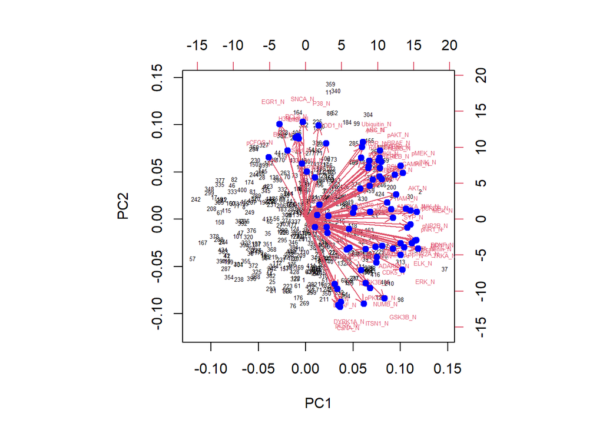

```r
biplot(train_pc, cex = 0.4, asp = 1);
# Note that the arrows are scaled by a factor of ca 17, hence the scaling below
points(x = 17 * train_pc$sdev[1] * train_pc$rotation[,1],
y = 17 * train_pc$sdev[2] * train_pc$rotation[,2],
col = "blue", pch = 20, cex = 1.5)
```

```r
summary(train_pc)
```

```
## Importance of components:
##                           PC1    PC2    PC3    PC4     PC5     PC6     PC7
## Standard deviation     4.8260 3.6883 2.7879 2.6716 1.79923 1.72076 1.53380
## Proportion of Variance 0.3025 0.1767 0.1009 0.0927 0.04204 0.03845 0.03055
## Cumulative Proportion  0.3025 0.4791 0.5801 0.6728 0.71481 0.75327 0.78382
##                            PC8     PC9    PC10    PC11   PC12    PC13    PC14
## Standard deviation     1.48328 1.37286 1.13649 1.06360 0.9926 0.91049 0.82860
## Proportion of Variance 0.02857 0.02448 0.01677 0.01469 0.0128 0.01077 0.00892
## Cumulative Proportion  0.81239 0.83687 0.85364 0.86834 0.8811 0.89190 0.90081
##                           PC15    PC16    PC17    PC18   PC19    PC20    PC21
## Standard deviation     0.77247 0.73465 0.70886 0.66285 0.6446 0.62835 0.61088
## Proportion of Variance 0.00775 0.00701 0.00653 0.00571 0.0054 0.00513 0.00485
## Cumulative Proportion  0.90856 0.91557 0.92210 0.92780 0.9332 0.93833 0.94318
##                           PC22    PC23    PC24    PC25   PC26    PC27    PC28
## Standard deviation     0.56109 0.53147 0.50309 0.49368 0.4646 0.45909 0.42500
## Proportion of Variance 0.00409 0.00367 0.00329 0.00317 0.0028 0.00274 0.00235
## Cumulative Proportion  0.94726 0.95093 0.95422 0.95738 0.9602 0.96292 0.96527
##                          PC29    PC30    PC31    PC32    PC33    PC34    PC35
## Standard deviation     0.4019 0.39491 0.38067 0.36008 0.35359 0.34941 0.34540
## Proportion of Variance 0.0021 0.00203 0.00188 0.00168 0.00162 0.00159 0.00155
## Cumulative Proportion  0.9674 0.96939 0.97128 0.97296 0.97458 0.97617 0.97772
##                           PC36    PC37   PC38    PC39    PC40    PC41    PC42
## Standard deviation     0.31959 0.31275 0.3035 0.29716 0.28661 0.27551 0.26420
## Proportion of Variance 0.00133 0.00127 0.0012 0.00115 0.00107 0.00099 0.00091
## Cumulative Proportion  0.97904 0.98031 0.9815 0.98266 0.98372 0.98471 0.98562
##                           PC43    PC44    PC45    PC46    PC47   PC48    PC49
## Standard deviation     0.26142 0.25752 0.24921 0.24663 0.23953 0.2317 0.23025
## Proportion of Variance 0.00089 0.00086 0.00081 0.00079 0.00075 0.0007 0.00069
## Cumulative Proportion  0.98650 0.98737 0.98817 0.98896 0.98971 0.9904 0.99109
##                           PC50    PC51   PC52    PC53    PC54   PC55    PC56
## Standard deviation     0.22778 0.22079 0.2145 0.20506 0.20077 0.1966 0.18891
## Proportion of Variance 0.00067 0.00063 0.0006 0.00055 0.00052 0.0005 0.00046
## Cumulative Proportion  0.99177 0.99240 0.9930 0.99354 0.99407 0.9946 0.99503
##                           PC57    PC58    PC59    PC60    PC61    PC62    PC63
## Standard deviation     0.18453 0.17822 0.17385 0.16826 0.16366 0.16084 0.16011
## Proportion of Variance 0.00044 0.00041 0.00039 0.00037 0.00035 0.00034 0.00033
## Cumulative Proportion  0.99547 0.99589 0.99628 0.99665 0.99700 0.99733 0.99766
##                          PC64    PC65    PC66    PC67    PC68    PC69    PC70
## Standard deviation     0.1518 0.14304 0.13847 0.13610 0.13115 0.12578 0.11344
## Proportion of Variance 0.0003 0.00027 0.00025 0.00024 0.00022 0.00021 0.00017
## Cumulative Proportion  0.9980 0.99823 0.99848 0.99872 0.99894 0.99915 0.99931
##                           PC71    PC72    PC73    PC74    PC75    PC76
## Standard deviation     0.10528 0.10001 0.09845 0.09152 0.08795 0.07652
## Proportion of Variance 0.00014 0.00013 0.00013 0.00011 0.00010 0.00008
## Cumulative Proportion  0.99946 0.99959 0.99971 0.99982 0.99992 1.00000
##                             PC77
## Standard deviation     2.896e-16
## Proportion of Variance 0.000e+00
## Cumulative Proportion  1.000e+00
```

**Results:** Major importance PC1 ~ 30% PC2 ~ 18% PC3 ~ 10% PC4 ~ 9%

Four first principal components explain ~67 percent of the variability in the input data.

```r
library(pca3d)
```

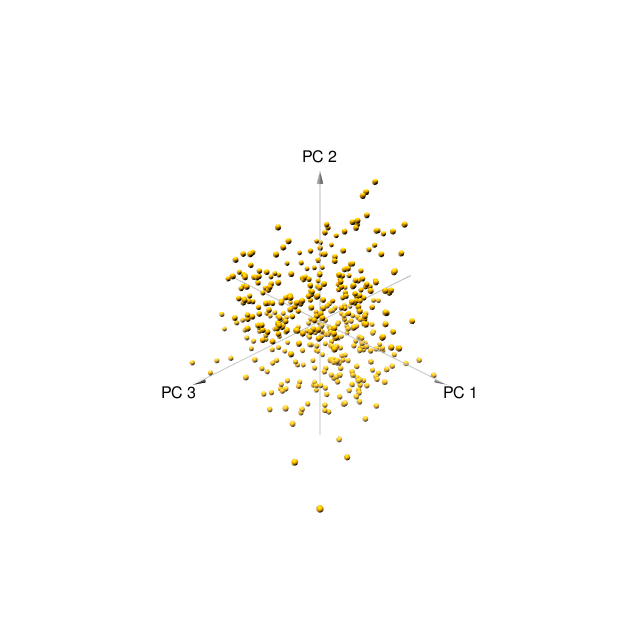

PCA 3d plot

```r
# pca3d(train_pc) #, group=gr)
# snapshotPCA3d(file="pca3d_plot.png")
```

## Task 5

**Search for differential proteins - the creative part of the task (15 points)**

- you can do a reanalysis from the article, but there is machine learning
- one of the solutions is to use directed ordination methods
- you can use limma/DeSeq2

### New groups for analysis:

**DEGs after treatment**

Non-treatment:

- c-SC-s: control mice, not stimulated to learn, injected with saline (9 mice)
- t-SC-s: trisomy mice, not stimulated to learn, injected with saline (9 mice)

Treatment:

- c-SC-m: control mice, not stimulated to learn, injected with memantine (10 mice)
- t-SC-m: trisomy mice, not stimulated to learn, injected with memantine (9 mice)

**DEGs after stimulation**

Non-stimulated:

- c-SC-s: control mice, not stimulated to learn, injected with saline (9 mice)
- t-SC-s: trisomy mice, not stimulated to learn, injected with saline (9 mice)

Stimulated:

- c-CS-s: control mice, stimulated to learn, injected with saline (9 mice)
- t-CS-s: trisomy mice, stimulated to learn, injected with saline (7 mice)

```r
completerecords$new_index <- paste(completerecords$class, completerecords$MouseID, sep = "_")
```

```r
library(data.table)
```

### DEGs after treatment

```r
# Set up the conditions based on the experimental setup.
names_nt  <-  c("c-SC-s", "t-SC-s")
names_t  <- c("c-SC-m", "t-SC-m")


non_tr <- rep("non_treatment", 2)
tr <- rep("treatment", 2)

samples <- c(names_nt, names_t)

condition <- factor(c(non_tr, tr))

colData = data.frame(samples=samples, condition=condition)
colData
```

```
##   samples     condition
## 1  c-SC-s non_treatment
## 2  t-SC-s non_treatment
## 3  c-SC-m     treatment
## 4  t-SC-m     treatment
```

```r
new_colData <- colData
colnames(new_colData) <- c("class", "condition")

new_completerecords <- merge(y=new_colData, x=completerecords, by="class", all.y = TRUE)

ind <- new_completerecords$new_index
new_drop <- c("MouseID", "Genotype",    "Treatment", "Behavior",    "class", "new_index", "condition")
new_m_df <- new_completerecords[,!(names(new_completerecords) %in% new_drop)]

new_m_df_trsp <- transpose(new_m_df)
```

```r
colnames(new_m_df_trsp) <- ind
rownames(new_m_df_trsp) <- colnames(new_m_df)
```

```r
new_colData2 <- new_completerecords[,(names(new_completerecords) %in% c("new_index", "condition"))]
colnames(new_colData2) <- c("samples", "condition")
```

```r
library(DESeq2)
```

```r
new_colData2$condition <- as.factor(new_colData2$condition)
```

```r
new_m_df_trsp_r <- new_m_df_trsp
new_m_df_trsp_r[] <- lapply(new_m_df_trsp, function(x) round(x*1000))
```

```r
# Create DESEq2 dataset.
dds = DESeqDataSetFromMatrix(countData=new_m_df_trsp_r, colData=new_colData2, design = ~condition)

#Set the reference to be compared
dds$condition = relevel(dds$condition,"non_treatment")

# Run deseq
dds = DESeq(dds)

# Format the results.
res = results(dds)

# Sort the results data frame by the padj and foldChange columns.
sorted = res[with(res, order(padj, -log2FoldChange)), ]

# Turn it into a dataframe to have proper column names.
sorted.df = data.frame("id"=rownames(sorted),sorted)

# Write the table out.
write.table(sorted.df, file="result_treatment.txt", sep="\t", col.names=NA, quote=FALSE)

# Get normalized counts and write this to a file
nc = counts(dds,normalized=TRUE)

# Turn it into a dataframe to have proper column names.
dt = data.frame("id"=rownames(nc),nc)

# Save the normalize data matrix.
write.table(dt, file="deg-treatment-deseq2.txt", sep="\t",  row.name=FALSE, col.names=TRUE,quote=FALSE)
```

```r
library(gplots)
```

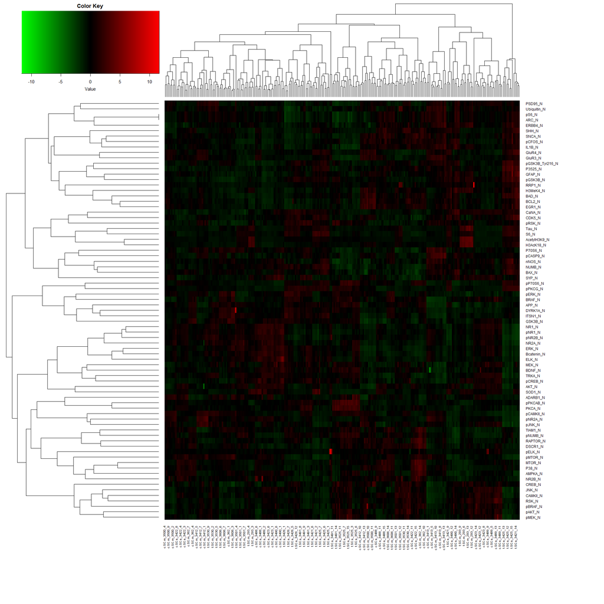

DEG HEATMAP

```r
# Read normalized counts
data = read.table("deg-treatment-deseq2.txt", header=T, sep="\t", as.is=TRUE)

gene = data[,1]
vals = as.matrix(data[,2:ncol(data)])

# Adds a little noise to each element
# To avoid the clusteing function failing on zero
# variance datalines.
vals = jitter(vals, factor = 1, amount=0.00001)


# Calculate zscore
score = NULL
for (i in 1:nrow(vals)) {
    row=vals[i,]
    zscore=(row-mean(row))/sd(row)
    score =rbind(score,zscore)
}

row.names(score) = gene
zscore=score

# Generate heatmap
mat = as.matrix(zscore)

# Open the drawing device
pdf("deg-treatment-heatmap2.pdf")
png(filename='deg_heatmap.png', width=2000, height=2000, pointsize=20)

colors = colorRampPalette(c("green","black","red"),space="rgb")(256)
heatmap.2(mat,col=colors,density.info="none",trace="none", margins=c(14,14),lhei=c(1,5))

invisible(dev.off())
```

#### The analysis of DEGs was made for the mementine treatment effect

**Overexpressed genes:** (Log2FoldChange > 0, adjusted p-value <0.005)

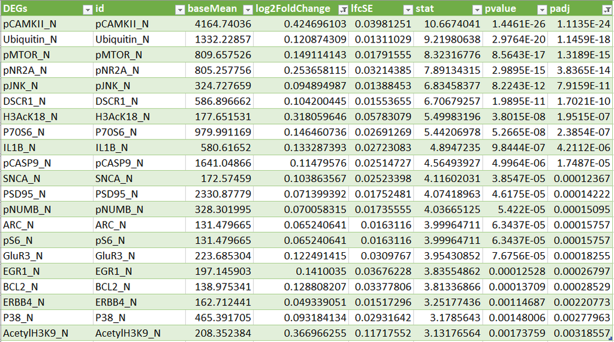

**Underexpressed genes:** (Log2FoldChange < 0, adjusted p-value <0.005)

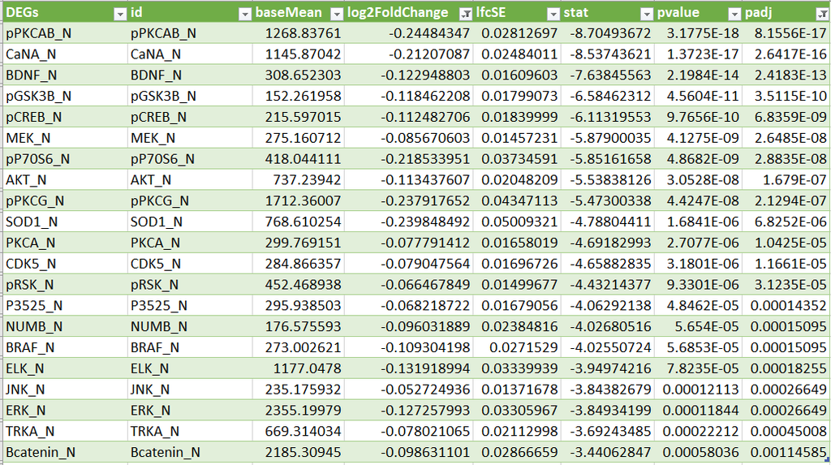

### DEGs after stimulation

```r
# Set up the conditions based on the experimental setup.
names_ns  <-  c("c-SC-s", "t-SC-s")
names_s  <- c("c-CS-s", "t-CS-s")


non_st <- rep("non_stimulated", 2)
st <- rep("stimulated", 2)

samples <- c(names_ns, names_s)

condition <- factor(c(non_st, st))

colData = data.frame(samples=samples, condition=condition)
colData
```

```
##   samples      condition
## 1  c-SC-s non_stimulated
## 2  t-SC-s non_stimulated
## 3  c-CS-s     stimulated
## 4  t-CS-s     stimulated
```

```r
new_colData <- colData
colnames(new_colData) <- c("class", "condition")

new_completerecords <- merge(y=new_colData, x=completerecords, by="class", all.y = TRUE)

ind <- new_completerecords$new_index
new_drop <- c("MouseID", "Genotype",    "Treatment", "Behavior",    "class", "new_index", "condition")
new_m_df <- new_completerecords[,!(names(new_completerecords) %in% new_drop)]

new_m_df_trsp <- transpose(new_m_df)
```

```r
colnames(new_m_df_trsp) <- ind
rownames(new_m_df_trsp) <- colnames(new_m_df)
```

```r
new_colData2 <- new_completerecords[,(names(new_completerecords) %in% c("new_index", "condition"))]
colnames(new_colData2) <- c("samples", "condition")
```

```r
new_colData2$condition <- as.factor(new_colData2$condition)
```

```r
new_m_df_trsp_r <- new_m_df_trsp
new_m_df_trsp_r[] <- lapply(new_m_df_trsp, function(x) round(x*1000))
```

```r
# Create DESEq2 dataset.
dds = DESeqDataSetFromMatrix(countData=new_m_df_trsp_r, colData=new_colData2, design = ~condition)

#Set the reference to be compared
dds$condition = relevel(dds$condition,"non_stimulated")

# Run deseq
dds = DESeq(dds)

# Format the results.
res = results(dds)

# Sort the results data frame by the padj and foldChange columns.
sorted = res[with(res, order(padj, -log2FoldChange)), ]

# Turn it into a dataframe to have proper column names.
sorted.df = data.frame("id"=rownames(sorted),sorted)

# Write the table out.
write.table(sorted.df, file="result_stimulated.txt", sep="\t", col.names=NA, quote=FALSE)

# Get normalized counts and write this to a file
nc = counts(dds,normalized=TRUE)

# Turn it into a dataframe to have proper column names.
dt = data.frame("id"=rownames(nc),nc)

# Save the normalize data matrix.
write.table(dt, file="deg-stimulation-deseq2.txt", sep="\t",  row.name=FALSE, col.names=TRUE,quote=FALSE)
```

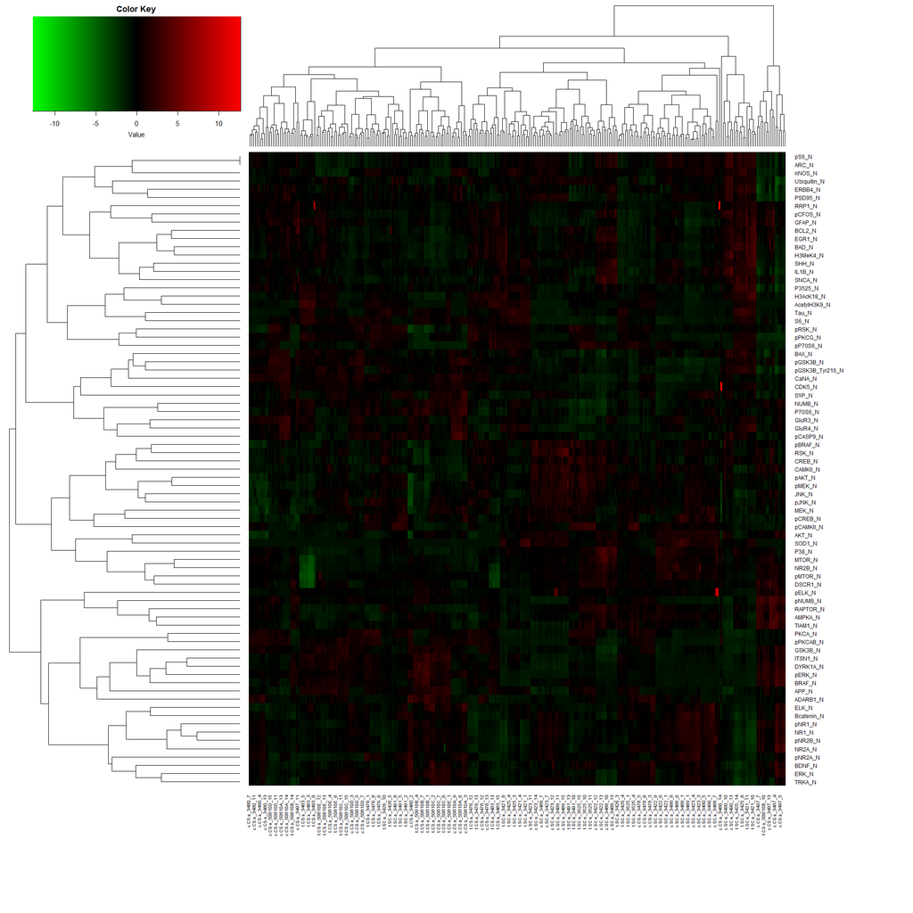

DEG HEATMAP

```r
# Read normalized counts
data = read.table("deg-stimulation-deseq2.txt", header=T, sep="\t", as.is=TRUE)

gene = data[,1]
vals = as.matrix(data[,2:ncol(data)])

# Adds a little noise to each element
# To avoid the clusteing function failing on zero
# variance datalines.
vals = jitter(vals, factor = 1, amount=0.00001)


# Calculate zscore
score = NULL
for (i in 1:nrow(vals)) {
    row=vals[i,]
    zscore=(row-mean(row))/sd(row)
    score =rbind(score,zscore)
}

row.names(score) = gene
zscore=score

# Generate heatmap
mat = as.matrix(zscore)

# Open the drawing device
pdf("deg-stimulation-heatmap2.pdf")
png(filename='deg_heatmap_st.png', width=2000, height=2000, pointsize=20)

colors = colorRampPalette(c("green","black","red"),space="rgb")(256)
heatmap.2(mat,col=colors,density.info="none",trace="none", margins=c(14,14),lhei=c(1,5))

invisible(dev.off())
```

#### The analysis of DEGs was made for stimulation to learn effect

**Overexpressed genes:** Log2FoldChange > 0, adjusted p-value < 0.005)

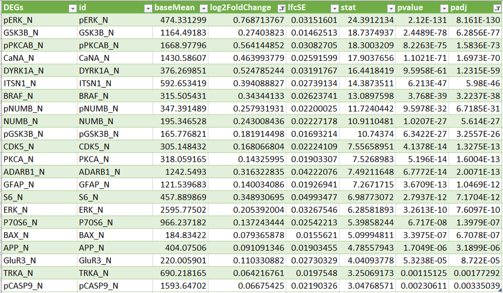

**Underexpressed genes:** Log2FoldChange < 0, adjusted p-value < 0.005)

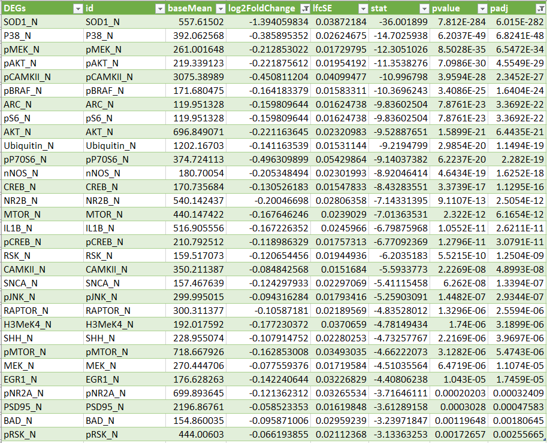

### Results:

**Overexpressed genes_Treatment VS Stimulation:** Log2FoldChange > 0, adjusted p-value < 0.005)

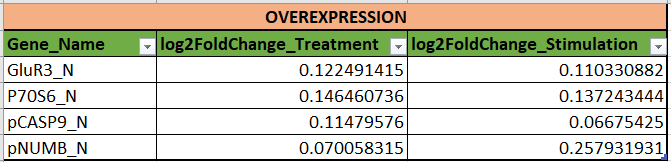

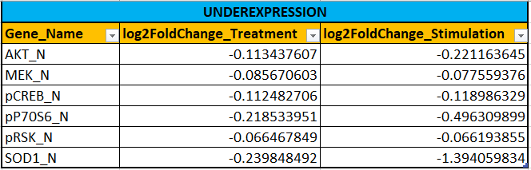

**As we can see, these genes similarly change expression under the influence of 2 different factors: memantine treatment and learning stimulation. As the conclusion, we can suggest, that these genes can be considered as targets for the forthcoming cognitive function research.**